# 05_analysis_3

## Loading library

```r
rm(list=ls())
library("tidyverse")
library("dplyr")
library("readr")
library('here')
library('ggplot2')
library('ggridges')
```

## Loading cancer data file

```r
# Loading the cleaned and augmented file:
cancer_data <- read_tsv(here('data/03_dat_aug.tsv'))
```

# Analysis of the 10 most prevalent medicines

A subset of the cancer data is made to investigate only the 10 most prevalent types of medicine. These medicines were identified through the descriptive statistics and appear to be the only ones exceeding 2% prevalence in the cancer dataset.

This analysis aims to investigate potential reasons explaining why these exact medicines appear as the most common in treatment of cancer.

### Subset of 10 most prevalent medicines

The subset is made for the 10 most prevalent medicines, by sorting via ID, as some medicine names might appear twice. A list of the medicine names is created, ranked from highest prevalence to lowest. This list is used to subset the cancer data by semi joining the ranked list and the cancer data using ID. Semi join is used in order to join row wise in the data.

```r
# Making list of 10 most prevalent drug ID's
Prevalent_10_medicine_names <- cancer_data |>
  # Sorting by unigue ID
  group_by(ID) |>
  # Finding prevalence of drugs
  summarise(Proportion = n() / nrow(cancer_data)) |>
  ungroup() |>
  # Arranging with descending order
  arrange(desc(Proportion)) |>
  # Taking 10 most prevelant
  slice_head(n = 10)


# Making subset of 10 most prevalent drug IDs
Most_prevalent_medicines <- cancer_data |>
  # Making subset by join using prevalence list
  semi_join(Prevalent_10_medicine_names,
            by = "ID")


# Viewing 10 most prevalent drug IDs
Most_prevalent_medicines |>
  distinct(ID,
           .keep_all = TRUE) |>
  head(10)
```

```
# A tibble: 10 × 20
      ID Medicine_Name Manufacturer       Administration_type Count_Side_Effects
   <dbl> <chr>         <chr>              <chr>                            <dbl>
 1     1 Avastin       Roche Products In… Injection                            9
 2     4 Anfoe         La Renon Healthca… Injection                           21
 3     5 Anfoe         La Renon Healthca… Injection                           21
 4     6 Anfoe         La Renon Healthca… Injection                           21
 5    10 Advacan       Biocon             Tablet                              11
 6    26 Espogen       LG Lifesciences    Injection                           21
 7    27 Eposis        Micro Labs Ltd     Injection                           21
 8    30 Eporise       Zuventus Healthca… Injection                           21
 9    69 Gemtaz        Sun Pharmaceutica… Injection                           14
10   129 Rolimus       Cipla Ltd          Tablet                              11
# ℹ 15 more variables: Count_API <dbl>, Count_Application <dbl>,
#   Classification_Review <chr>, Application_number <chr>,
#   Application_type <chr>, API_name_number <chr>, API_name <chr>,
#   API_amount_number <chr>, API_amount <dbl>, API_unit_number <chr>,
#   API_unit <chr>, Review_level <chr>, `Review_%` <dbl>,
#   Side_Effect_number <chr>, Side_Effect_type <chr>
```

The subset shows the 10 most prevalent drugs in the cancer data. From the dimension of the data frame, 10 disitinct ID’s appear

## Relationship of Prevalent Drugs with Corresponding Side Effects and Administration Type

The relationship between the most prevalent medicine names and the number of side effects is investigated, as it is plausible, that a lower number of side effects might explain a higher usage, making the drug more common. As we only aim to investigate unique medicine names, we make sure to distinguish by this in the pipeline of plotting. As the medicines will carry the same API, active pharmaceutical ingredients, the number of side effects will not differ, making the subset valid. The administration type is furthermore highlighted for each drug, as this is also a plausible variable affecting popularity and consumption.

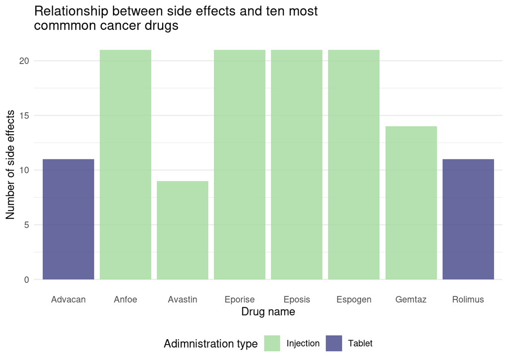

```r
Most_prevalent_medicines_plot <- Most_prevalent_medicines |>
  # Sorting and grouping by medicine name
  distinct(Medicine_Name,
           .keep_all = TRUE) |>
  group_by(Medicine_Name) |>
  # Looking at unique numbers of side effects for each drug
  distinct(Count_Side_Effects,
           .keep_all = TRUE) |>
  # Plotting bar plot of side effect number pr. drug
  ggplot(aes(x = Medicine_Name,
             y = Count_Side_Effects,
             fill=Administration_type)) +
  geom_bar(stat= 'identity',
           alpha = 0.8) +
  scale_fill_manual(values =c('#A1D99B',
                              '#414487FF')) +
  labs(x = "Drug name",
       y = "Number of side effects") +
  ggtitle(str_wrap("Relationship between side effects and ten most commmon cancer drugs", 50)) +
  theme_minimal() +
  theme(legend.position = 'bottom') +
  guides(fill=guide_legend(title="Adimnistration type")) +
  theme(panel.grid.major.x = element_blank(),  # Remove major vertical grid lines
        panel.grid.minor.x = element_blank())

ggsave(here("results/Most_prevalent_medicines_plot.png"), plot = Most_prevalent_medicines_plot, width = 6, height = 4)

print(Most_prevalent_medicines_plot)
```

The visualization only yields 8 different types of drug names, which is explained by one of the drugs, Anfoe, appearing three times out of the ten most prevalent, simply in different doses. Hence only 8 unique medicines exceed a prevalence of 2%. The distribution of side effects seems random, if not dominated by a rather high number of side effects. The number of side effects does therefore not seem to be the cause of the popularity of the prevalent drugs.

Furthermore, it appears, from the visualization, that administration type ‘Injection’ is related to 75% of the 8 unique drugs. Only ‘Tablet’ and ‘Injection’ are present as administration types for the 8 drugs.

A higher number of side effects also seem to be associated with administration of the drug via injection. To investigate this trend further, the density of side effects related to each of the different administration types is visualized in the cancer data with the aim of finding a general trend. This is done for each of the medicines by using the ID in order to obtain unique observations.

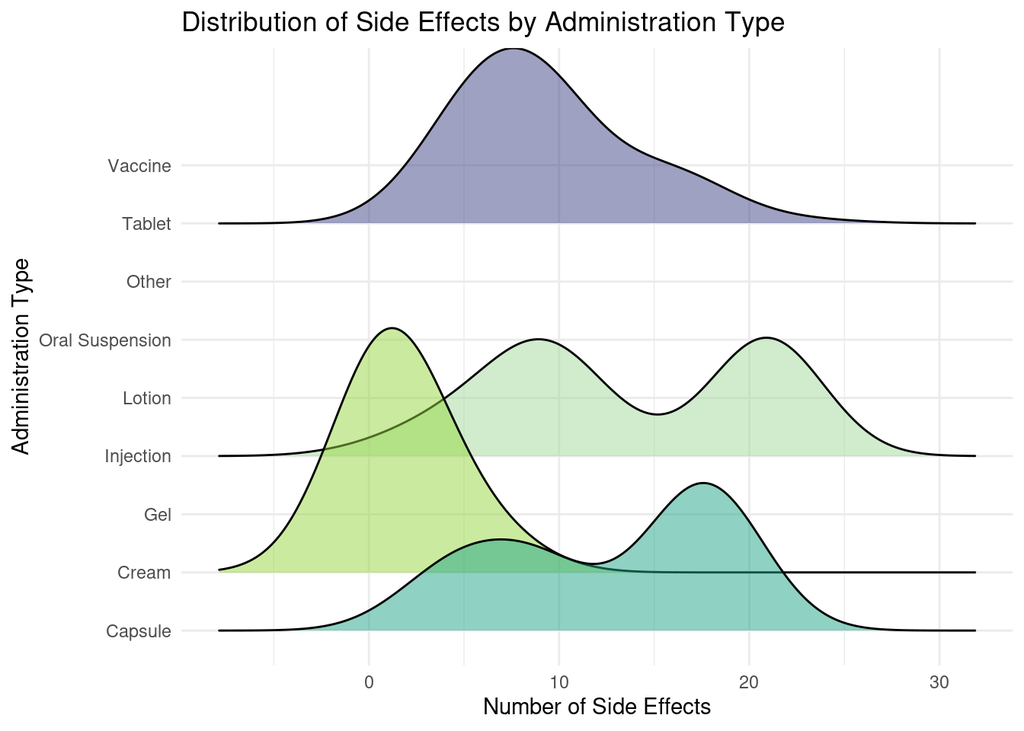

```r
Side_Effects_Administration_type <- cancer_data |>
   distinct(ID,
           Administration_type,
           Count_Side_Effects,
           .keep_all = TRUE) |>
  # Using type of administration and side effect number from cancer data
  select(Administration_type,
         Count_Side_Effects) |>
  # Plotting density of side effects for each administration type
  ggplot(aes(
    x = Count_Side_Effects,
    y = as.factor(Administration_type),
    fill = as.factor(Administration_type)
  )) +
  # Including transparency due to overlap of density plots
  geom_density_ridges(alpha = 0.5) +
  scale_fill_manual(values =c('#20A387FF',
                              '#95D840FF',
                              '#A1D99B',
                              '#414487FF',
                              '#E6550D',
                              '#FDE725FF',
                              '#D6616B',
                              '#DE9ED6FF' ,
                              '#440154FF' ))  +
  theme_minimal() +
  theme(legend.position = 'none') +
  labs(
    title = "Distribution of Side Effects by Administration Type",
    x = "Number of Side Effects",
    y = "Administration Type",
    fill = "Administration Type"
  )


ggsave(here("results/Side_Effects_Administration_type.png"), plot = Side_Effects_Administration_type, width = 6, height = 4)
print(Side_Effects_Administration_type)
```

The density plot shows a general trend between Injection and a medium to high number of side effects. The peak at ~20 confirms what is found in the subset of the prevalent drugs. Furthermore, a peak in the density of side effects aorund ~10 is observed for tablets, which is in accordance with tablet-administrated drugs Advancan and Rolimus in the prevalence medicine subset.

## Relationship between Prevalent Drugs and Reviews Level

The relationship between the most common cancer drugs and review level is investigated for each unique ID. We look at each ID since we are interested in the prevalence of each review level. The investigation is performed by creating a subset only containing information on ID, medicine name, and classification of review yielding a data frame.

```r
Most_prevalent_medicines |>
  # Using ID to dinstinguish observations
  group_by(ID) |>
  # Selecting variables of interest
  distinct(ID, Medicine_Name,
           Classification_Review) |>
  # Arranging data in alphabetical order
  arrange(Classification_Review) |>
  head(10)
```

```
# A tibble: 10 × 3
# Groups:   ID [10]
      ID Medicine_Name Classification_Review
   <dbl> <chr>         <chr>
 1     1 Avastin       Average
 2     4 Anfoe         Average
 3    27 Eposis        Average
 4    30 Eporise       Average
 5     5 Anfoe         Excellent
 6     6 Anfoe         Excellent
 7    10 Advacan       Excellent
 8    69 Gemtaz        Excellent
 9   129 Rolimus       Excellent
10    26 Espogen       Poor
```

The data frame shows 10 unique ID’s, which can also found in the descriptive analysis. The drug Anfoe appears three times, supporting results from earlier. From the classification of review, the levels of average and excellent are somewhat appearing at the same frequency, 4 and 5 times respectively, whereas the review level poor only appear once. This indicates that a poor review might potentially affect the prescription and/or choice of a drug.